# Red Wine Quality by Eduardo Dionisio Gamarra

> **O conjunto de dados**: O conjunto de dados é um arquivo csv contendo 1599 observações sobre vinhos tintos, com 13 variáveis associadas a eles (1 variável de ID + 11 variáveis de atributos + 1 variável de saída).

> **A questão principal**: A principal questão é descobrir: quais propriedades químicas influenciam a qualidade dos vinhos tintos? Tentarei responder à pergunta executando a Análise Exploratória de Dados (EDA) do conjunto de dados.

# Seção Gráficos univariados

#### Estrutura e resumo do conjunto de dados

Vamos dar uma olhada em como nossos dados estão estruturados.

```
## 'data.frame':    1599 obs. of  13 variables:
##  $ X                   : int  1 2 3 4 5 6 7 8 9 10 ...
##  $ fixed.acidity       : num  7.4 7.8 7.8 11.2 7.4 7.4 7.9 7.3 7.8 7.5 ...
##  $ volatile.acidity    : num  0.7 0.88 0.76 0.28 0.7 0.66 0.6 0.65 0.58 0.5 ...
##  $ citric.acid         : num  0 0 0.04 0.56 0 0 0.06 0 0.02 0.36 ...
##  $ residual.sugar      : num  1.9 2.6 2.3 1.9 1.9 1.8 1.6 1.2 2 6.1 ...
##  $ chlorides           : num  0.076 0.098 0.092 0.075 0.076 0.075 0.069 0.065 0.073 0.071 ...
##  $ free.sulfur.dioxide : num  11 25 15 17 11 13 15 15 9 17 ...
##  $ total.sulfur.dioxide: num  34 67 54 60 34 40 59 21 18 102 ...
##  $ density             : num  0.998 0.997 0.997 0.998 0.998 ...
##  $ pH                  : num  3.51 3.2 3.26 3.16 3.51 3.51 3.3 3.39 3.36 3.35 ...
##  $ sulphates           : num  0.56 0.68 0.65 0.58 0.56 0.56 0.46 0.47 0.57 0.8 ...
##  $ alcohol             : num  9.4 9.8 9.8 9.8 9.4 9.4 9.4 10 9.5 10.5 ...
##  $ quality             : int  5 5 5 6 5 5 5 7 7 5 ...
```

```
##        X          fixed.acidity   volatile.acidity  citric.acid
##  Min.   :   1.0   Min.   : 4.60   Min.   :0.1200   Min.   :0.000
##  1st Qu.: 400.5   1st Qu.: 7.10   1st Qu.:0.3900   1st Qu.:0.090
##  Median : 800.0   Median : 7.90   Median :0.5200   Median :0.260
##  Mean   : 800.0   Mean   : 8.32   Mean   :0.5278   Mean   :0.271
##  3rd Qu.:1199.5   3rd Qu.: 9.20   3rd Qu.:0.6400   3rd Qu.:0.420
##  Max.   :1599.0   Max.   :15.90   Max.   :1.5800   Max.   :1.000
##  residual.sugar     chlorides       free.sulfur.dioxide
##  Min.   : 0.900   Min.   :0.01200   Min.   : 1.00
##  1st Qu.: 1.900   1st Qu.:0.07000   1st Qu.: 7.00
##  Median : 2.200   Median :0.07900   Median :14.00
##  Mean   : 2.539   Mean   :0.08747   Mean   :15.87
##  3rd Qu.: 2.600   3rd Qu.:0.09000   3rd Qu.:21.00
##  Max.   :15.500   Max.   :0.61100   Max.   :72.00
##  total.sulfur.dioxide    density             pH          sulphates
##  Min.   :  6.00       Min.   :0.9901   Min.   :2.740   Min.   :0.3300
##  1st Qu.: 22.00       1st Qu.:0.9956   1st Qu.:3.210   1st Qu.:0.5500
##  Median : 38.00       Median :0.9968   Median :3.310   Median :0.6200
##  Mean   : 46.47       Mean   :0.9967   Mean   :3.311   Mean   :0.6581
##  3rd Qu.: 62.00       3rd Qu.:0.9978   3rd Qu.:3.400   3rd Qu.:0.7300
##  Max.   :289.00       Max.   :1.0037   Max.   :4.010   Max.   :2.0000
##     alcohol         quality
##  Min.   : 8.40   Min.   :3.000
##  1st Qu.: 9.50   1st Qu.:5.000
##  Median :10.20   Median :6.000
##  Mean   :10.42   Mean   :5.636
##  3rd Qu.:11.10   3rd Qu.:6.000
##  Max.   :14.90   Max.   :8.000
```

Vou fazer algumas alterações no conjunto de dados: Primeiro, estou renomeando a variável ‘X’ para ‘wine.id’ para torná-la mais intuitiva. Eu também acho que é uma boa idéia transformar a variável ‘qualidade’ de um Inteiro em um Fator. E por último, vou criar uma variável fatorial ‘rank’ para melhor classificação de qualidade, será (ruim, médio e bom)

Agora vamos visualizar a estrutura após as alterações.

```
## 'data.frame':    1599 obs. of  14 variables:
##  $ wine.id             : int  1 2 3 4 5 6 7 8 9 10 ...
##  $ fixed.acidity       : num  7.4 7.8 7.8 11.2 7.4 7.4 7.9 7.3 7.8 7.5 ...
##  $ volatile.acidity    : num  0.7 0.88 0.76 0.28 0.7 0.66 0.6 0.65 0.58 0.5 ...
##  $ citric.acid         : num  0 0 0.04 0.56 0 0 0.06 0 0.02 0.36 ...
##  $ residual.sugar      : num  1.9 2.6 2.3 1.9 1.9 1.8 1.6 1.2 2 6.1 ...
##  $ chlorides           : num  0.076 0.098 0.092 0.075 0.076 0.075 0.069 0.065 0.073 0.071 ...
##  $ free.sulfur.dioxide : num  11 25 15 17 11 13 15 15 9 17 ...
##  $ total.sulfur.dioxide: num  34 67 54 60 34 40 59 21 18 102 ...
##  $ density             : num  0.998 0.997 0.997 0.998 0.998 ...
##  $ pH                  : num  3.51 3.2 3.26 3.16 3.51 3.51 3.3 3.39 3.36 3.35 ...
##  $ sulphates           : num  0.56 0.68 0.65 0.58 0.56 0.56 0.46 0.47 0.57 0.8 ...
##  $ alcohol             : num  9.4 9.8 9.8 9.8 9.4 9.4 9.4 10 9.5 10.5 ...
##  $ quality             : Ord.factor w/ 6 levels "3"<"4"<"5"<"6"<..: 3 3 3 4 3 3 3 5 5 3 ...
##  $ rank                : Ord.factor w/ 3 levels "bad"<"medium"<..: 2 2 2 2 2 2 2 3 3 2 ...
```

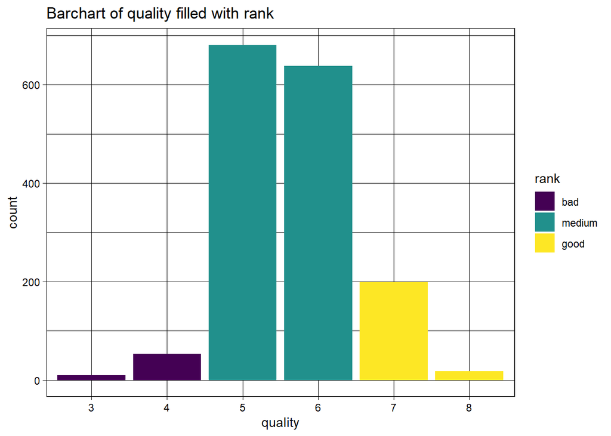

O gráfico corresponde à documentação do conjunto de dados que indica que as classes não são equilibradas, a maioria dos vinhos tem qualidade média. Vou explorar a distribuição das variáveis:

#### Fixed acidity

acidez fixa (ácido tartárico - g / dm ^ 3): a maioria dos ácidos envolvidos no vinho ou fixa ou não volátil (não evapora rapidamente).

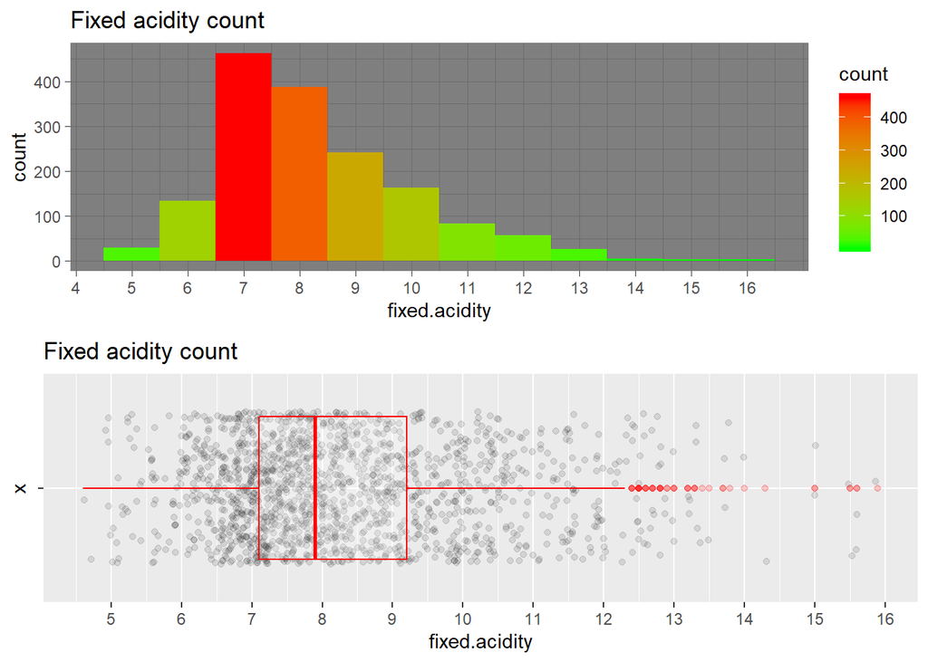

```
##    Min. 1st Qu.  Median    Mean 3rd Qu.    Max.
##    4.60    7.10    7.90    8.32    9.20   15.90
```

Parece que a distribuição de Acidez fixa está distorcida positivamente. A mediana é de cerca de 8 e, devido a alguns valores discrepantes, o quartil 3 foi arrastado para cerca de 9,2.

#### Volatile acidity

acidez volátil (ácido acético - g / dm ^ 3): a quantidade de ácido acético no vinho, que em níveis muito altos pode levar a um sabor desagradável ao vinagre.

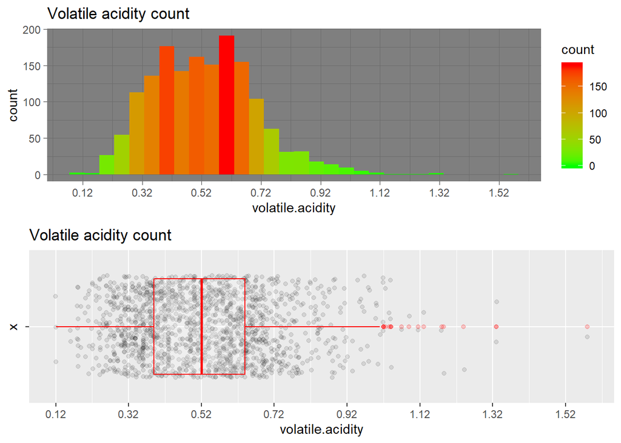

Parece que a distribuição da volatilidade também é distorcida positivamente. com dois picos em 0,4 e 0,6.

#### Citric acid

ácido cítrico (g / dm ^ 3): encontrado em pequenas quantidades, o ácido cítrico pode adicionar ‘refrescância’ e sabor aos vinhos.

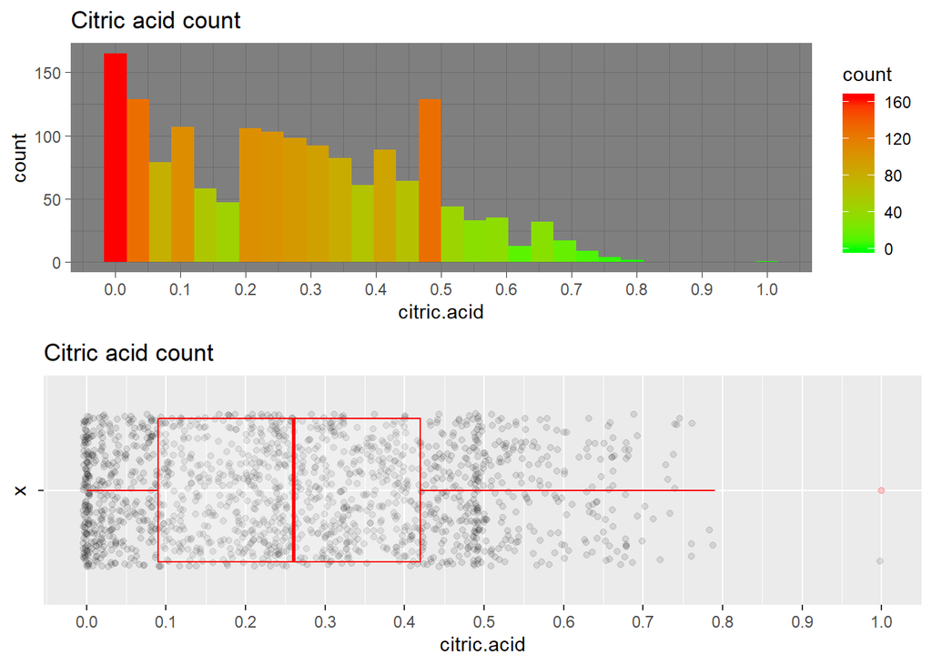

Este é um pouco difícil de adivinhar se é inclinado apenas olhando o histograma, mas a posição da caixa está à esquerda do gráfico, o que sugere que é um gráfico de caixa inclinado à direita; portanto, consideraremos que uma distribuição inclinada positivamente .

#### Residual sugar

açúcar residual (g / dm ^ 3): a quantidade de açúcar restante após a fermentação para, é raro encontrar vinhos com menos de 1 grama / litro e vinhos com mais de 45 gramas / litro são considerados doces.

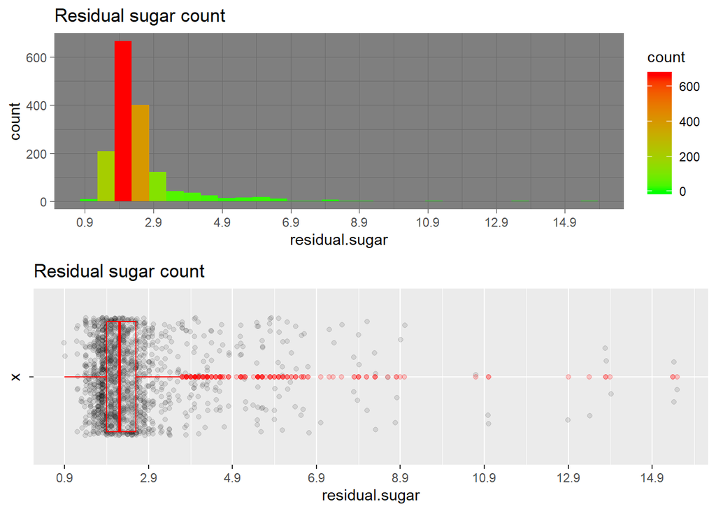

Esta é uma distribuição de log tail. Pode ser transformado removendo alguns discrepantes (5%) e aplicando uma transformação de log.

#### Chlorides

cloretos (cloreto de sódio - g / dm ^ 3): a quantidade de sal no vinho.

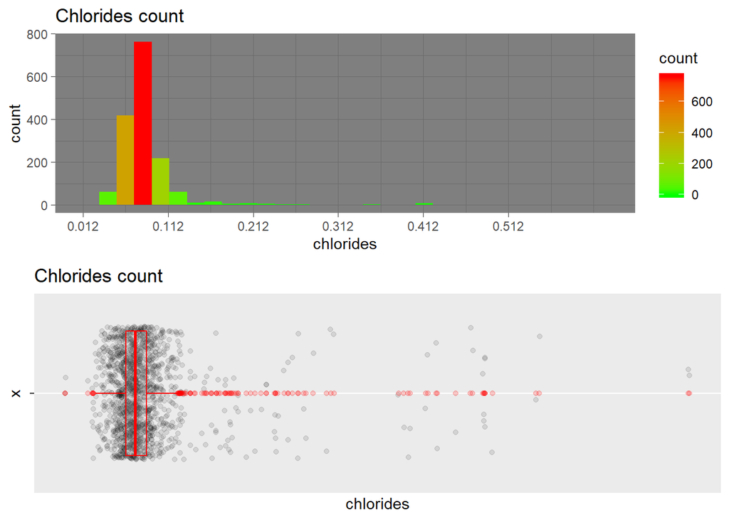

Este também é uma distribuição de cauda longa. Como o anterior, ele pode ser transformado removendo alguns discrepantes (5%) e aplicando uma transformação de log.

#### Free sulfur dioxide

dióxido de enxofre livre (mg / dm ^ 3): a forma livre de SO2 existe em equilíbrio entre o SO2 molecular (como um gás dissolvido) e o íon bissulfito; impede o crescimento microbiano e a oxidação do vinho.

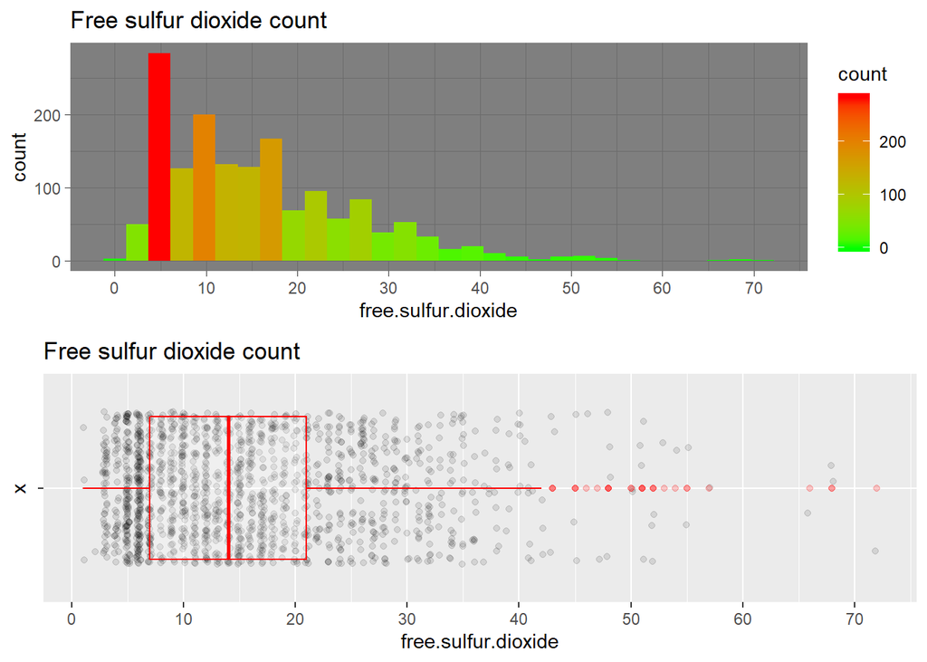

A distribuição do free.sulfur.dioxide é inclinada positivamente.

#### Total sulfur dioxide

dióxido de enxofre total (mg / dm ^ 3): a quantidade de formas livres e ligadas de S02; em baixas concentrações, o SO2 é principalmente indetectável no vinho, mas em concentrações livres de SO2 acima de 50 ppm, o SO2 se torna evidente no nariz e no sabor do vinho.

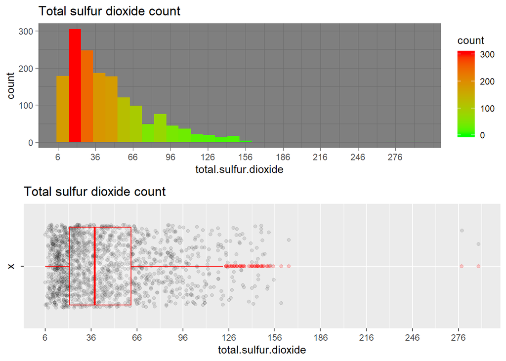

olhando os gráficos, podemos dizer que essa distribuição é uma cauda longa, mas eu prefiro classificá-la como uma distorção positiva, porque se você remover os outliers (5%), você terminará com um gráfico muito mais razoável .

#### Density

densidade (g / cm ^ 3): a densidade do vinho é próxima à da água, dependendo da porcentagem de álcool e açúcar.

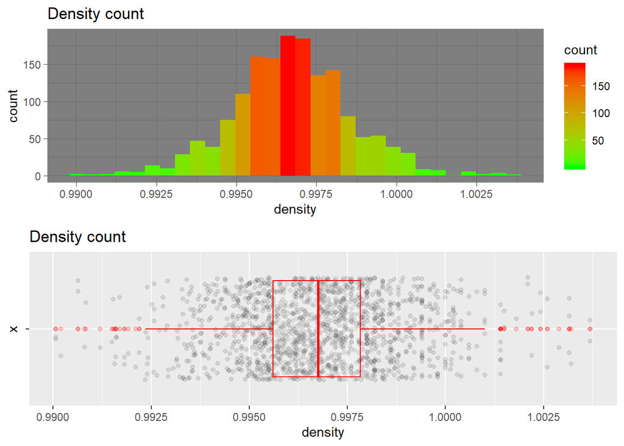

A densidade tem uma distribuição normal.

#### pH

pH: descreve como um vinho é ácido ou básico em uma escala de 0 (muito ácido) a 14 (muito básico); a maioria dos vinhos tem entre 3-4 na escala de pH.

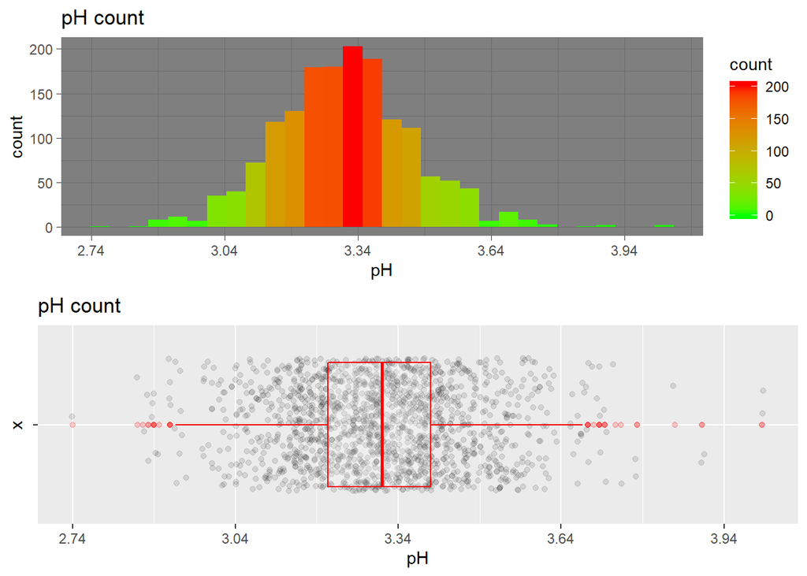

A distribuição do pH tem uma distribuição normal.

#### Sulphates (potassium sulphate - g / dm3)

sulfatos: aditivo de vinho que pode contribuir para os níveis de gás dióxido de enxofre (S02), que atua como antimicrobiano e antioxidante.

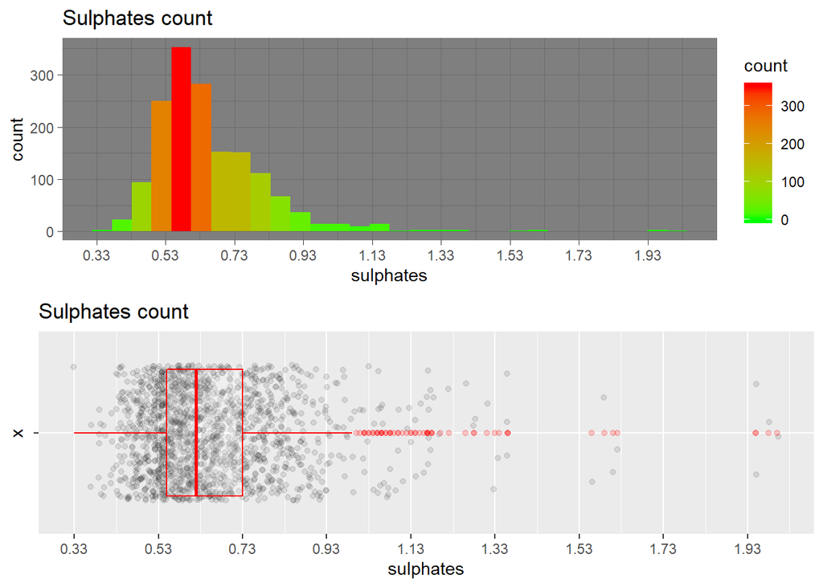

Como esta variável está relacionada ao enxofre, não é surpresa que a distribuição esteja inclinada positivamente.

#### Alcohol

Álcool (% em volume): o percentual de teor alcoólico do vinho.

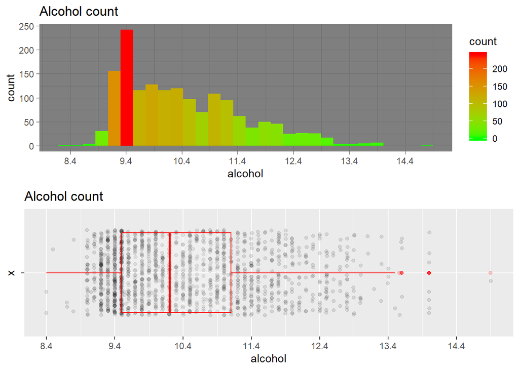

A distribuição do álcool é ligeiramente inclinada positivamente.

Conclusão:

- *Positivamente enviesado*: acidez fixa, acidez volátil, ácido cítrico, dióxido de enxofre livre, dióxido de enxofre total, sulfatos, álcool
- *Cauda longa* : açúcar residual, cloretos
- *Normal*: densidade, PH

# Análise univariada

### Qual é a estrutura do seu conjunto de dados?

O conjunto de dados do vinho tinto teve 1599 observações e 13 variáveis originalmente. Eu adicionei uma variável chamada ‘rank’. O conjunto de dados é organizado de forma organizada, e a maioria dos valores são float (num) trecho x (agora wine.id) e qualidade.

### Qual é / são os principais recursos de interesse em seu conjunto de dados?

Estou interessado nos componentes químicos, então não estou interessado em densidade ou ph (não ignorarei as variáveis para medir o impacto dos componentes químicos na qualidade).

### Que outros recursos do conjunto de dados você acha que ajudarão a apoiar sua investigação sobre seus recursos de interesse?

Qualidade e classificação, porque elas me ajudarão a entender a quantidade de impacto que cada componente químico causará na qualidade.

### Você criou novas variáveis a partir de variáveis existentes no conjunto de dados?

Sim, eu criei a classificação variável, uma variável categórica.

### Dos recursos que você investigou, houve alguma distribuição incomum? Você executou alguma operação nos dados para arrumar, ajustar ou alterar a forma dos dados? Se sim, por que você fez isso?

Não havia necessidade de alterar ou ajustar os dados, os valores discrepantes parecem valores de dados verdadeiros e não erros de entrada. As distribuições encontradas nos dados foram principalmente inclinadas positivamente.

# Seção Gráficos bivariados

A documentação diz que várias das variáveis podem estar correlacionadas, vamos começar olhando para ela.

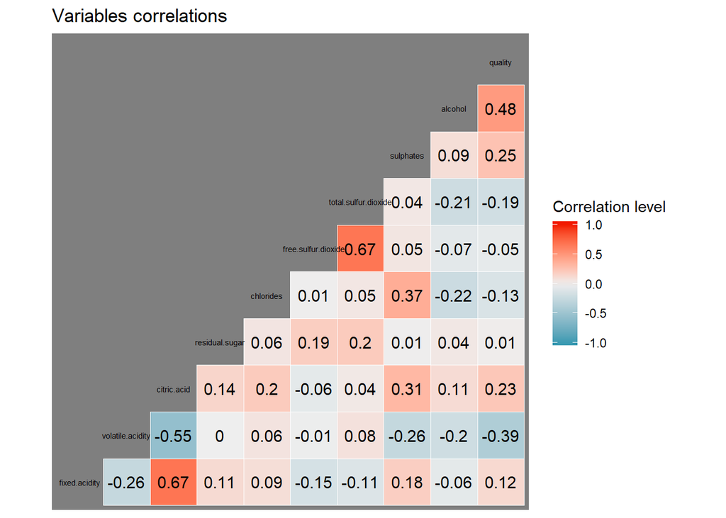

álcool | 0,48  
volatile.acidity | -0,39  
sulfatos | 0,25  
citric.acid | 0,23

Vamos dar uma olhada nessas quatro variáveis.

#### Qualidade versus álcool

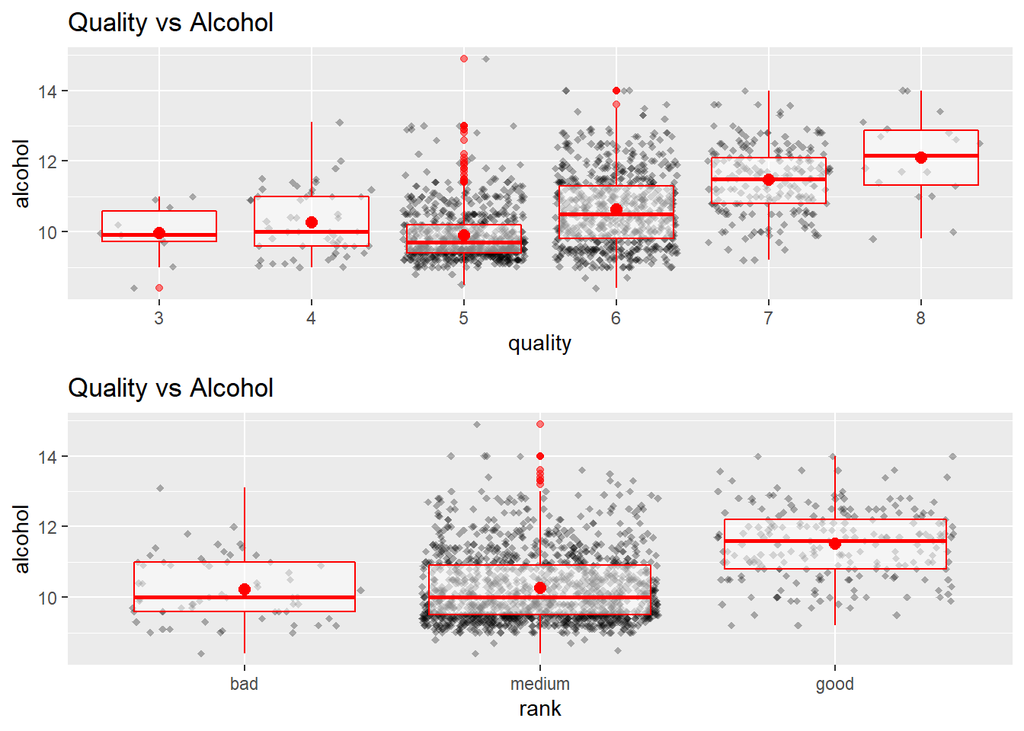

O gráfico deixa claro que vinhos de alta qualidade têm maior teor alcoólico.

Agora vamos traçar a acidez volátil.

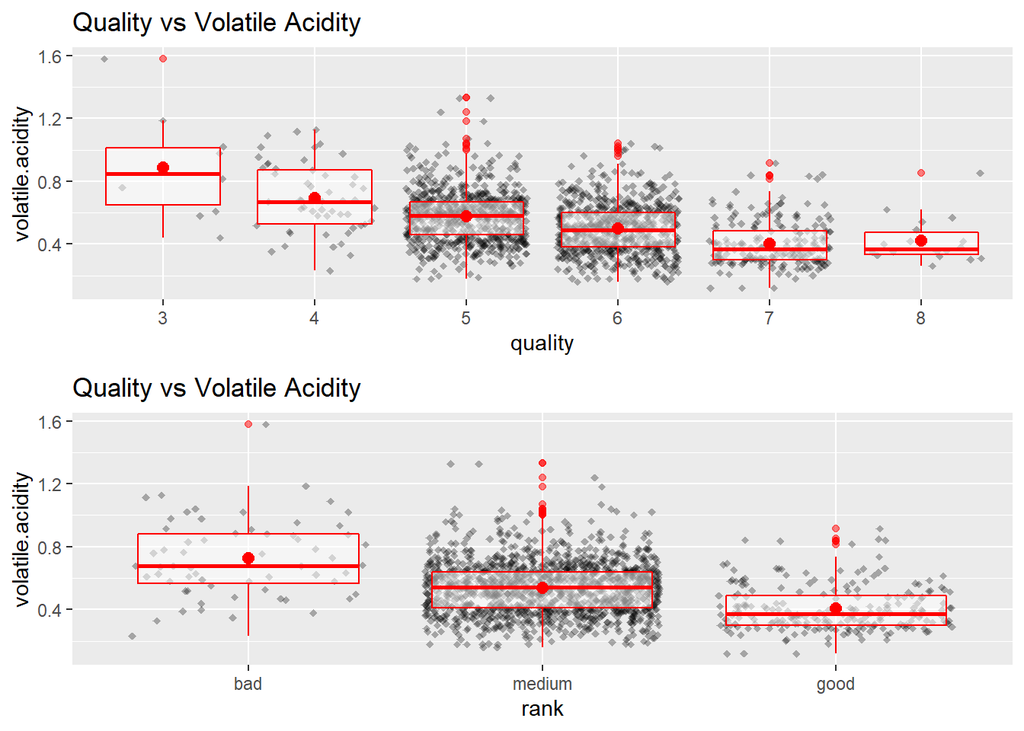

Como podemos ver, a variável ácido volátil parece ter uma influência negativa sobre o vinho, porque à medida que o nível de ácido volátil sobe, a qualidade / classificação do vinho diminui.

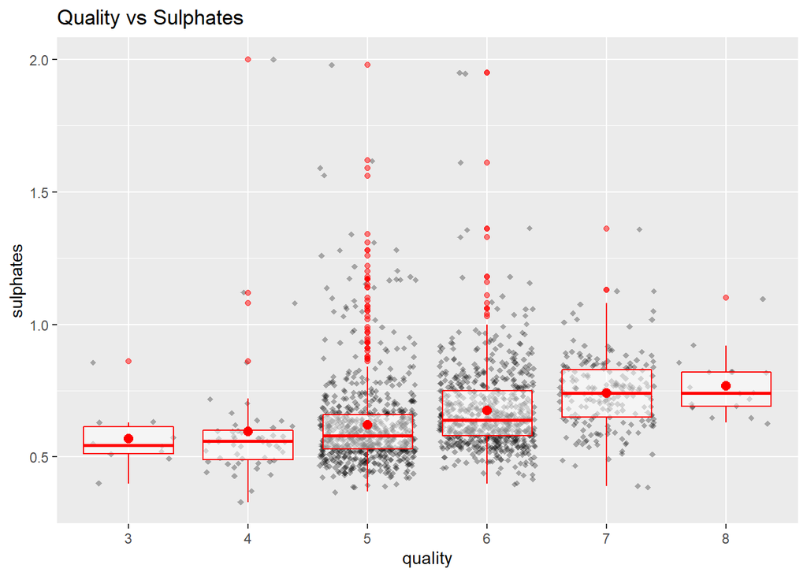

Podemos ver que os vinhos com um valor de qualidade mais alto com mais sulfatos do que outros com menos quantidade de sulfatos.

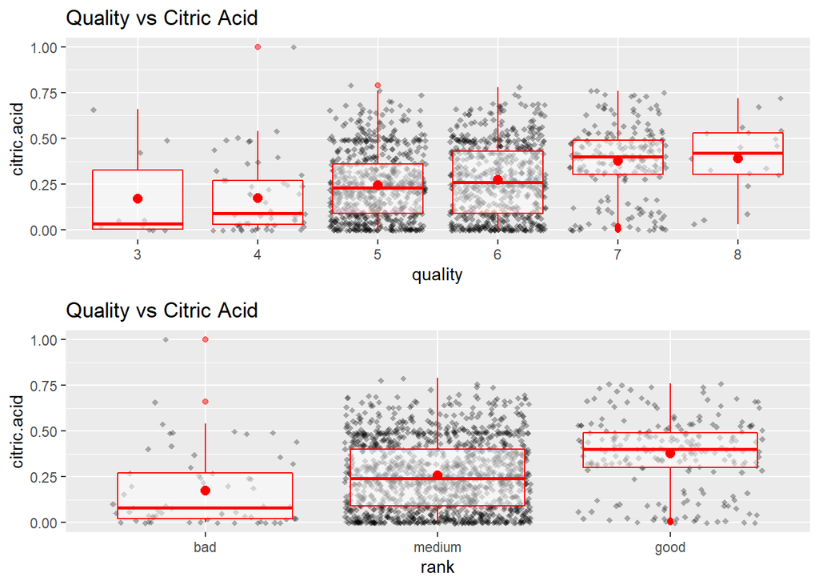

WPodemos ver que o ácido cítrico tem uma correlação positiva com a qualidade do vinho.

# Análise bivariada

Fale sobre alguns dos relacionamentos que você observou nesta parte da investigação. Como os recursos de interesse variaram com outros recursos no conjunto de dados?

Eu escolhi:

A acidez volátil teve uma correlação negativa de -0,39.

Os sulfatos têm uma correlação positiva de 0,25

### Você observou algum relacionamento interessante entre os outros recursos (não os principais recursos de interesse)?

Eu encontrei a relação entre o dióxido de enxofre livre e o dióxido de enxofre total com 0,67 de correlação positiva.

# Seção de gráficos multivariados

O álcool parece ter um papel importante na qualidade do vinho, então agora tentarei inserir mais algumas variáveis para analisar o quanto elas contribuem para a qualidade geral.

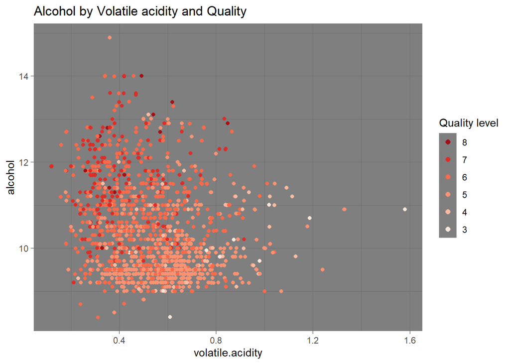

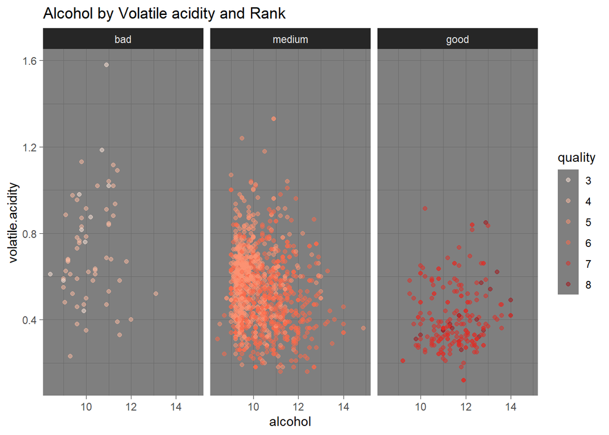

Aqui podemos ver que a maioria dos bons vinhos tem valores de álcool acima de 11% e perto de 0,4 de acidez volátil.

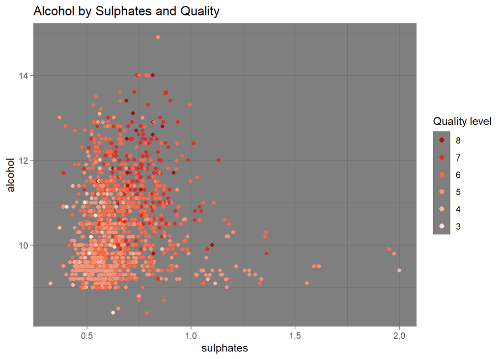

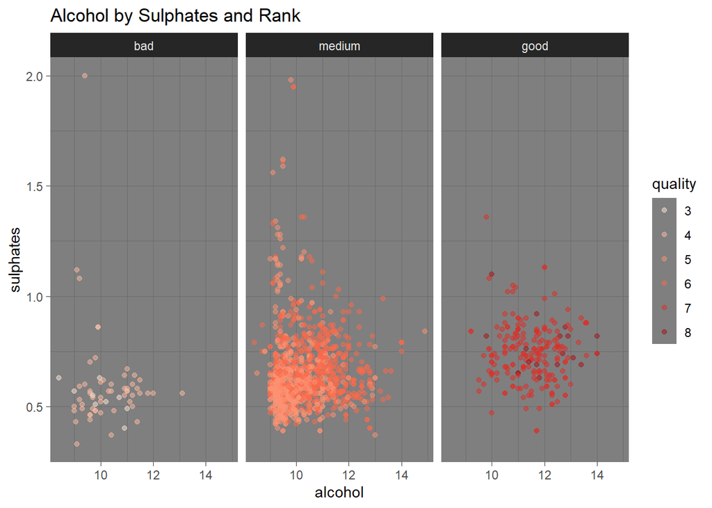

A maioria dos bons vinhos tem valores de álcool acima de 11% e entre 0,5 e 1 de sulfatos, resultando em vinhos de qualidade 7 ou superior.

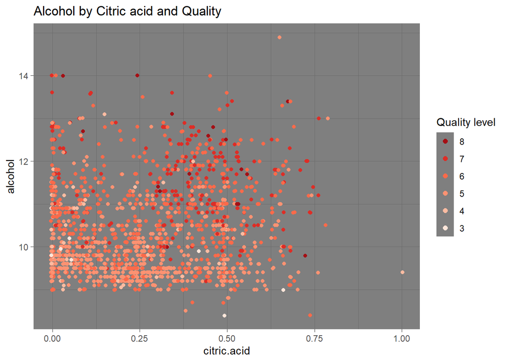

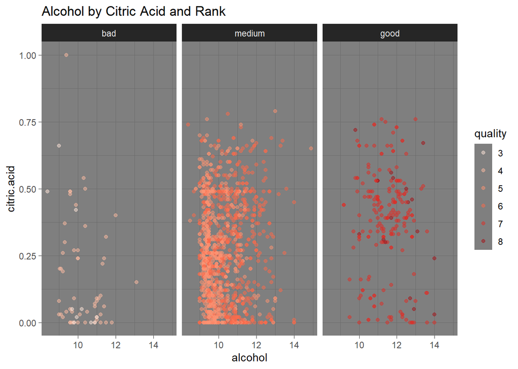

A maioria dos bons vinhos tem valores de álcool acima de 11% e 0,25 de ácido cítrico, resultando em vinhos de qualidade 7 e acima

# Modelo linear multivariável

Este modelo linear foi criado para prever a qualidade do vinho com base nas principais propriedades químicas. Os recursos são selecionados na ordem da correlação entre esse recurso e a qualidade do vinho.

```r
set.seed(1221)

sample_data <- sample_frac(wines, .6)

test_data <- wines[ !wines$wine.id %in% sample_data$wines$wine.id, ]
m1 <- lm(as.numeric(quality) ~ alcohol, data = wines)
m2 <- update(m1, ~ . + volatile.acidity)
m3 <- update(m2, ~ . + sulphates)
m4 <- update(m3, ~ . + citric.acid)
mtable(m1,m2,m3,m4)
```

```
##
## Calls:
## m1: lm(formula = as.numeric(quality) ~ alcohol, data = wines)
## m2: lm(formula = as.numeric(quality) ~ alcohol + volatile.acidity,
##     data = wines)
## m3: lm(formula = as.numeric(quality) ~ alcohol + volatile.acidity +
##     sulphates, data = wines)
## m4: lm(formula = as.numeric(quality) ~ alcohol + volatile.acidity +
##     sulphates + citric.acid, data = wines)
##
## ========================================================================
##                         m1           m2           m3           m4
## ------------------------------------------------------------------------
##   (Intercept)         -0.125        1.095***     0.611**      0.646**
##                       (0.175)      (0.184)      (0.196)      (0.201)
##   alcohol              0.361***     0.314***     0.309***     0.309***
##                       (0.017)      (0.016)      (0.016)      (0.016)
##   volatile.acidity                 -1.384***    -1.221***    -1.265***
##                                    (0.095)      (0.097)      (0.113)
##   sulphates                                      0.679***     0.696***
##                                                 (0.101)      (0.103)
##   citric.acid                                                -0.079
##                                                              (0.104)
## ------------------------------------------------------------------------
##   R-squared            0.227        0.317        0.336        0.336
##   N                 1599         1599         1599         1599
## ========================================================================
##   Significance: *** = p < 0.001; ** = p < 0.01; * = p < 0.05
```

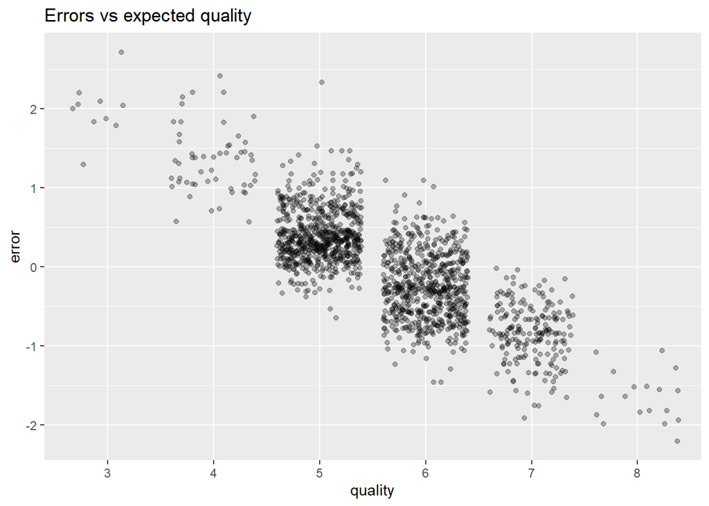

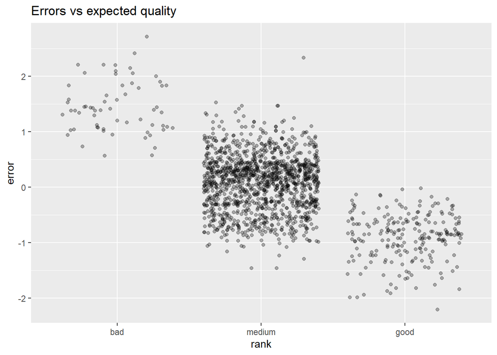

# Análise multivariada

Fale sobre alguns dos relacionamentos que você observou nesta parte da investigação. Havia recursos que se fortaleceram em termos de olhar para os seus recursos de interesse?

### OPCIONAL: Você criou modelos com seu conjunto de dados? Discuta os pontos fortes e as limitações do seu modelo.

Sim, o modelo linear de 4 características foi criado para prever a qualidade do vinho usando essas características. No entanto, a qualidade do vinho é um objeto complexo, precisa de mais variáveis para ser corretamente prevista. O principal problema desse insue foi que não havia dados estatísticos suficientes para ter um nível de confiança significativo nas equações produzidas.

## Como nosso conjunto de dados é composto principalmente por vinhos de qualidade “Média” e como há muito poucos dados sobre os vinhos de qualidade “Bom” e “Ruim” no conjunto de dados, pode ser difícil prever estatísticas para os casos extremos.

# Gráficos Finais e Resumo

### Gráfico um

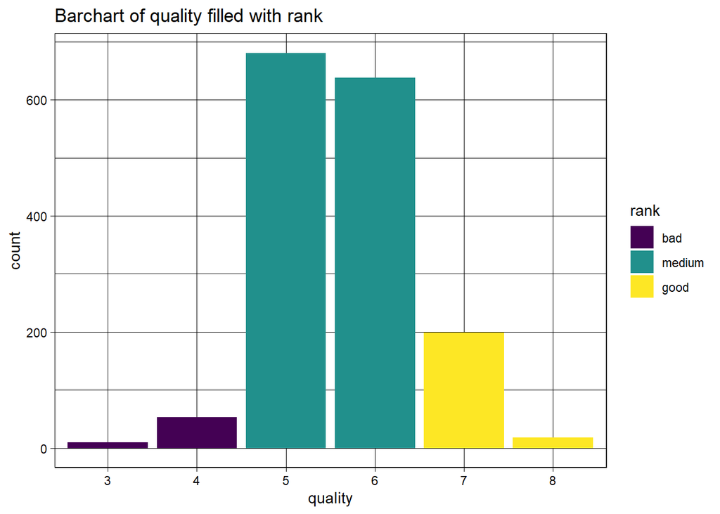

### Descrição Um

Este gráfico é importante, mostra como os nossos dados são distribuídos e nos dá a ideia de que os dados estão desequilibrados. Precisamos ter isso em mente ao analisar as variáveis.

### Gráfico dois

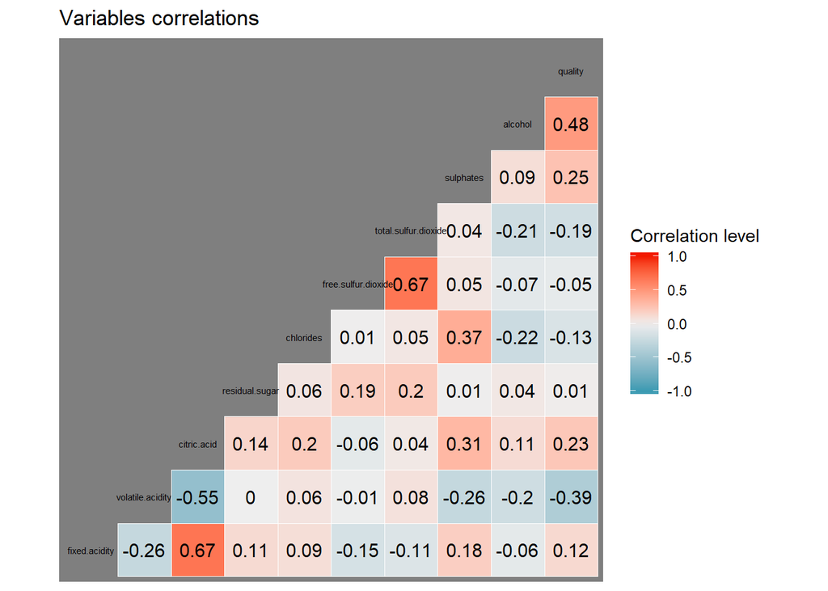

### Descrição Dois

Eu acho que esse gráfico é importante, mostra a correlação entre nossas variáveis, com ele escolhemos quais variáveis usaremos para analisar para encontrar a resposta para a pergunta principal. Observe que este está focado nas variáveis químicas, então eu não incluí as variáveis de densidade e pH.

### Gráfico Três

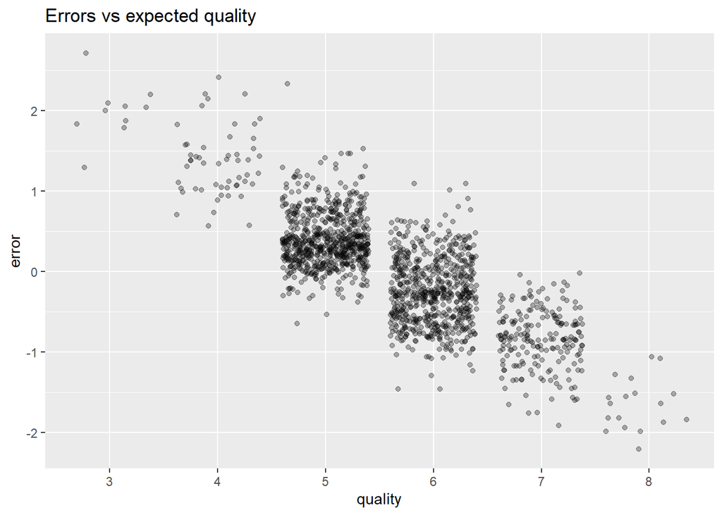

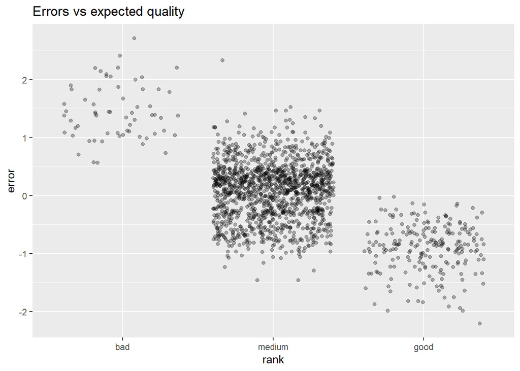

### Descrição três

Este gráfico mostra a densidade dos dados em torno do nível médio de qualidade. Isso corrobora com a plotagem da contagem de qualidade e registrou o fato de que a maior parte do nosso conjunto de dados contém vinhos de qualidade “média” e não há muitos dados nos intervalos extremos. com dificuldade a tarefa do melhor modelo para prever vinhos de qualidade “boa” e “ruim”.

# Reflexão

O conjunto de dados do vinho tinto contém 1.599 observações, 13 variáveis associadas a eles (1 variável de identificação + 11 variáveis de atributos + 1 variável de saída). Examinando a documentação, ele especifica que o conjunto de dados não é equilibrado e analisando o quanto o conjunto de dados está desequilibrado. O conjunto de dados para vinhos de qualidade média cobre mais de 80% da distribuição.

Além disso, a documentação menciona que o conjunto completo de dados possui o número de instâncias: vinho tinto - 1599; vinho branco - 4898.

Com isso, eu sabia que as correlações poderiam ser alteradas e que meu modelo linear teria mais dificuldade em prever vinhos bons e ruins do que os médios.

Essas variáveis são:

Álcool: O fator N.1 se correlacionou com a qualidade do vinho. Os dados sugerem que quanto maior o teor de álcool, maior a probabilidade de melhor qualidade do vinho com 0,48.

Acidez volátil: a acidez volátil tem a correlação negativa mais forte com a qualidade do vinho com -0,39.

Sulfatos: Os sulfatos têm uma correlação positiva com a qualidade do vinho com 0,25.

Ácidos cítricos: tem uma correlação positiva com a qualidade do vinho com 0,23.

Se o conjunto de dados tivesse mais observações com vinhos bons e ruins, a qualidade da análise seria muito melhor, tendo essas observações e talvez mais algumas variáveis incluídas, o conjunto de dados resultaria em uma percepção totalmente diferente sobre a análise.